# Descriptive Statistics and Table 1 in R

- Show All Code
- Hide All Code
- View Source

How to summarise cleaned clinical research data before formal analysis

Author

Ziyao Geng, RISE Education Team

**NoteHow to use this article**

This article builds on Articles 1 and 2.

Article 1 introduced R basics. Article 2 cleaned a messy clinical research dataset. In this article, we use the cleaned dataset to create descriptive summaries, a simple Table 1, exploratory plots, and first group comparisons.

## 1. Why descriptive statistics come before statistical tests

Before running formal statistical tests, we need to understand the dataset.

Descriptive statistics help us answer basic questions:

- How many participants are in the dataset?
- What is the typical age, BMI, blood pressure, or HbA1c?
- How many participants have diabetes?
- Are there missing values?
- Are the groups roughly similar or clearly different?
- Do the distributions look sensible?

## 2. Load packages

We will use a few beginner-friendly packages:

- `tidyverse` for data manipulation and plotting;
- `janitor` for simple data-cleaning helpers;
- `knitr` for making cleaner tables in the rendered HTML article.

```r
# Run this installation code only if these packages are not already installed.
# You do not need to run install.packages() every time you open the file.
install.packages(c("tidyverse", "janitor", "knitr"))
```

```r
# Load packages for this article.
library(tidyverse)
library(janitor)
library(knitr)

# Create folders for outputs if they do not already exist.
# showWarnings = FALSE prevents R from complaining if the folder already exists.
dir.create("outputs", showWarnings = FALSE)
dir.create("figures", showWarnings = FALSE)

# This option tells knitr to display missing values as blank cells in kable tables.
# That usually looks cleaner than printing "NA" repeatedly in a table.
options(knitr.kable.NA = "")
```

## 3. Import the cleaned dataset

This article uses the cleaned dataset from Article 2. The expected file path is:

```
data/rise_sample_health_data_cleaned.csv
```

```r
# Store the file path in one object so that it is easy to change later.
data_path <- "data/rise_sample_health_data_cleaned.csv"

# Stop early with a helpful error message if the file is not found.
# This is easier for beginners to understand than a long read_csv() error.
if (!file.exists(data_path)) {
  stop("Cannot find the cleaned dataset. Check that rise_sample_health_data_cleaned.csv is inside the data/ folder.")
}

# Import the cleaned dataset.
# show_col_types = FALSE hides a long message about guessed column types.
clean_data <- read_csv(data_path, show_col_types = FALSE)
```

Inspect the data before doing anything else.

```r
# glimpse() gives a compact overview of column names, data types, and example values.
glimpse(clean_data)
```

```
Rows: 80
Columns: 12
$ participant_id            <chr> "RISE001", "RISE002", "RISE003", "RISE004", …
$ age                       <dbl> 56, 69, 72, NA, 29, 19, 67, 21, 23, 37, 34, …
$ sex                       <chr> "Female", "Female", "Male", "Female", "Male"…
$ bmi                       <dbl> 20.0, 19.5, 27.3, 27.7, 25.3, 26.7, 27.4, 29…
$ systolic_bp               <dbl> 129, 132, 152, 117, 114, 122, 148, 108, 120,…
$ diastolic_bp              <dbl> 73, 89, 69, 67, 67, 80, 82, 60, 70, 73, 69, …
$ hba1c_mmol_mol            <dbl> 35.0, 57.9, 66.3, 39.4, 34.1, 32.1, 43.6, 29…
$ smoking_status            <chr> "Never", "Never", "Former", "Former", "Forme…
$ diabetes_status           <chr> "No", "Yes", "Yes", "No", NA, "No", "Yes", "…
$ recruitment_site          <chr> "Metro Hospital", "Metro Hospital", "Regiona…
$ study_group               <chr> "Control", "Control", "Control", "Control", …
$ exercise_minutes_per_week <dbl> 292, 54, 22, 240, 259, NA, 171, 129, 202, 19…
```

```r
# head() prints the first six rows.
head(clean_data)
```

```
# A tibble: 6 × 12
  participant_id   age sex      bmi systolic_bp diastolic_bp hba1c_mmol_mol
  <chr>          <dbl> <chr>  <dbl>       <dbl>        <dbl>          <dbl>
1 RISE001           56 Female  20           129           73           35
2 RISE002           69 Female  19.5         132           89           57.9
3 RISE003           72 Male    27.3         152           69           66.3
4 RISE004           NA Female  27.7         117           67           39.4
5 RISE005           29 Male    25.3         114           67           34.1
6 RISE006           19 Female  26.7         122           80           32.1
# ℹ 5 more variables: smoking_status <chr>, diabetes_status <chr>,
#   recruitment_site <chr>, study_group <chr>, exercise_minutes_per_week <dbl>
```

## 4. Decide which variables to summarise

For this article, we will separate variables into two broad groups.

```r
# Continuous variables are numeric measurements.
# Examples: age, BMI, blood pressure, and HbA1c.
continuous_vars <- c(
  "age",
  "bmi",
  "systolic_bp",
  "diastolic_bp",
  "hba1c_mmol_mol",
  "exercise_minutes_per_week"
)

# Categorical variables are groups or labels.
# Examples: sex, smoking status, diabetes status, and recruitment site.
categorical_vars <- c(
  "sex",
  "smoking_status",
  "diabetes_status",
  "recruitment_site",
  "study_group"
)
```

It is also useful to create readable labels for variables. These labels will make our tables easier to read.

```r
# Named character vectors are a simple way to translate internal column names
# into reader-friendly table labels.
variable_labels <- c(
  age = "Age (years)",
  bmi = "BMI (kg/m²)",
  systolic_bp = "Systolic blood pressure (mmHg)",
  diastolic_bp = "Diastolic blood pressure (mmHg)",
  hba1c_mmol_mol = "HbA1c (mmol/mol)",
  exercise_minutes_per_week = "Exercise minutes per week",
  sex = "Sex",
  smoking_status = "Smoking status",
  diabetes_status = "Diabetes status",
  recruitment_site = "Recruitment site",
  study_group = "Study group"
)

# This helper function replaces column names with the labels above.
# If a variable is not listed in variable_labels, it creates a simple label
# by replacing underscores with spaces.
label_variables <- function(x) {
  labelled <- unname(variable_labels[x])
  fallback <- str_to_sentence(str_replace_all(x, "_", " "))
  if_else(is.na(labelled), fallback, labelled)
}
```

## 5. Count missing values

Even after cleaning, some missing values may remain. That is normal. The important thing is to know where they are.

```r
# For each column, count how many values are missing.
# is.na(.x) returns TRUE for missing values.
# sum(is.na(.x)) counts the TRUE values.
missing_summary <- clean_data %>%
  summarise(across(everything(), ~ sum(is.na(.x)))) %>%
  pivot_longer(
    cols = everything(),
    names_to = "variable",
    values_to = "missing_n"
  ) %>%
  arrange(desc(missing_n))

# Create a display version with nicer variable names.
missing_summary_display <- missing_summary %>%
  mutate(variable = label_variables(variable)) %>%
  rename(
    Variable = variable,
    `Missing values` = missing_n
  )

# Display the table neatly in the rendered HTML article.
kable(
  missing_summary_display,
  caption = "Missing values by variable",
  align = "l",
  table.attr = 'class="table table-striped table-hover"'
)
```

Missing values by variable

| Variable | Missing values |
| --- | --- |
| BMI (kg/m²) | 5 |
| Exercise minutes per week | 4 |
| Age (years) | 3 |
| HbA1c (mmol/mol) | 3 |
| Sex | 2 |
| Diabetes status | 2 |
| Systolic blood pressure (mmHg) | 1 |
| Diastolic blood pressure (mmHg) | 1 |
| Smoking status | 1 |
| Participant id | 0 |
| Recruitment site | 0 |
| Study group | 0 |

```r
# Save the raw missing-value summary as a CSV file.
write_csv(missing_summary, "outputs/article_03_missing_summary.csv")
```

## 6. Summarise continuous variables

For continuous variables, common summaries include:

- number of non-missing observations;
- mean;
- standard deviation;
- median;
- interquartile range;
- minimum and maximum.

```r
# Summarise all continuous variables at once.
# across() applies the same summary functions to every selected variable.
continuous_summary <- clean_data %>%
  summarise(
    across(
      all_of(continuous_vars),
      list(
        n = ~ sum(!is.na(.x)),
        mean = ~ mean(.x, na.rm = TRUE),
        sd = ~ sd(.x, na.rm = TRUE),
        median = ~ median(.x, na.rm = TRUE),
        q1 = ~ quantile(.x, 0.25, na.rm = TRUE),
        q3 = ~ quantile(.x, 0.75, na.rm = TRUE),
        min = ~ min(.x, na.rm = TRUE),
        max = ~ max(.x, na.rm = TRUE)
      ),
      .names = "{.col}_{.fn}"
    )
  ) %>%
  pivot_longer(
    cols = everything(),
    names_to = c("variable", ".value"),
    names_pattern = "(.*)_(n|mean|sd|median|q1|q3|min|max)$"
  ) %>%
  mutate(
    across(where(is.numeric), ~ round(.x, 1))
  )

# Create a display version with clearer column names.
continuous_summary_display <- continuous_summary %>%
  mutate(variable = label_variables(variable)) %>%
  rename(
    Variable = variable,
    N = n,
    Mean = mean,
    SD = sd,
    Median = median,
    Q1 = q1,
    Q3 = q3,
    Minimum = min,
    Maximum = max
  )

kable(
  continuous_summary_display,
  caption = "Summary of continuous variables",
  digits = 1,
  align = "l",
  table.attr = 'class="table table-striped table-hover"'
)
```

Summary of continuous variables

| Variable | N | Mean | SD | Median | Q1 | Q3 | Minimum | Maximum |
| --- | --- | --- | --- | --- | --- | --- | --- | --- |
| Age (years) | 77 | 44.5 | 16.3 | 44.0 | 30.0 | 57.0 | 19.0 | 74.0 |
| BMI (kg/m²) | 75 | 27.3 | 5.1 | 27.4 | 23.1 | 30.9 | 18.2 | 40.8 |
| Systolic blood pressure (mmHg) | 79 | 127.1 | 12.3 | 127.0 | 118.0 | 136.0 | 97.0 | 153.0 |
| Diastolic blood pressure (mmHg) | 79 | 73.7 | 7.7 | 74.0 | 68.5 | 79.5 | 53.0 | 97.0 |
| HbA1c (mmol/mol) | 77 | 42.0 | 12.6 | 37.5 | 32.5 | 47.3 | 27.0 | 85.2 |
| Exercise minutes per week | 76 | 151.1 | 86.9 | 151.5 | 78.8 | 222.5 | 0.0 | 317.0 |

```r
# Save the continuous-variable summary as a CSV file.
write_csv(continuous_summary, "outputs/article_03_continuous_summary.csv")
```

## 7. Summarise categorical variables

For categorical variables, we usually report counts and percentages.

```r
# Convert categorical columns into a long format.
# This makes it easy to count each category within each variable.
categorical_summary <- clean_data %>%
  select(all_of(categorical_vars)) %>%
  pivot_longer(
    cols = everything(),
    names_to = "variable",
    values_to = "category"
  ) %>%
  filter(!is.na(category)) %>%
  count(variable, category, name = "n") %>%
  group_by(variable) %>%
  mutate(
    percent = round(100 * n / sum(n), 1),
    result = paste0(n, " (", percent, "%)")
  ) %>%
  ungroup()

# Create a display version with nicer labels.
categorical_summary_display <- categorical_summary %>%
  mutate(variable = label_variables(variable)) %>%
  rename(
    Variable = variable,
    Category = category,
    N = n,
    Percent = percent,
    `n (%)` = result
  )

kable(
  categorical_summary_display,
  caption = "Summary of categorical variables",
  digits = 1,
  align = "l",
  table.attr = 'class="table table-striped table-hover"'
)
```

Summary of categorical variables

| Variable | Category | N | Percent | n (%) |
| --- | --- | --- | --- | --- |
| Diabetes status | No | 55 | 70.5 | 55 (70.5%) |
| Diabetes status | Yes | 23 | 29.5 | 23 (29.5%) |
| Recruitment site | Metro Hospital | 30 | 37.5 | 30 (37.5%) |
| Recruitment site | Regional Clinic | 21 | 26.2 | 21 (26.2%) |
| Recruitment site | University Clinic | 29 | 36.2 | 29 (36.2%) |
| Sex | Female | 45 | 57.7 | 45 (57.7%) |
| Sex | Male | 33 | 42.3 | 33 (42.3%) |
| Smoking status | Current | 10 | 12.7 | 10 (12.7%) |
| Smoking status | Former | 17 | 21.5 | 17 (21.5%) |
| Smoking status | Never | 52 | 65.8 | 52 (65.8%) |
| Study group | Control | 39 | 48.8 | 39 (48.8%) |
| Study group | Intervention | 41 | 51.2 | 41 (51.2%) |

```r
# Save the categorical-variable summary as a CSV file.
write_csv(categorical_summary, "outputs/article_03_categorical_summary.csv")
```

## 8. What is a Table 1?

A **Table 1** is a baseline characteristics table. It is common in clinical papers.

It usually describes the study population using variables such as age, sex, BMI, comorbidities, blood pressure, and laboratory values.

For example, a Table 1 might show:

- median age and interquartile range;
- number and percentage of female and male participants;
- median BMI and blood pressure;
- smoking status;
- baseline disease status;
- number of participants in each study group.

## 9. Make prettier tables with `kable()`

By default, R prints data frames in a plain console style. That is fine while coding, but it does not always look professional in a rendered article.

The `kable()` function from the `knitr` package converts a data frame into a cleaner table.

The basic pattern is:

```r
# Basic kable structure:
kable(
  your_data_frame,
  caption = "Your table title here"
)
```

For this article, we will use the following slightly more polished version:

```r
kable(
  your_data_frame,
  caption = "Your table title here",
  digits = 1,
  align = "l",
  table.attr = 'class="table table-striped table-hover"'
)
```

What each argument means:

- `caption` adds a title above the table;
- `digits` controls how many decimal places are shown for numeric columns;
- `align = "l"` left-aligns table columns;
- `table.attr` adds Bootstrap table styling in the rendered HTML file.

## 10. Create a simple overall Table 1

To keep this article beginner-friendly, we will create a simple Table 1 using `dplyr` rather than specialised Table 1 packages.

First, we create small helper functions to format values consistently.

```r
# Format a continuous variable as median [Q1, Q3].
# This is a common clinical Table 1 style when variables are skewed.
format_median_iqr <- function(median, q1, q3, digits = 1) {
  paste0(
    round(median, digits),
    " [",
    round(q1, digits),
    ", ",
    round(q3, digits),
    "]"
  )
}

# Format a categorical variable as n (%).
format_n_percent <- function(n, percent, digits = 1) {
  paste0(n, " (", round(percent, digits), "%)")
}
```

Create the continuous-variable part of Table 1.

```r
# Use the continuous summary created earlier.
# Each continuous variable becomes one row in the Table 1.
table1_continuous <- continuous_summary %>%
  transmute(
    Characteristic = label_variables(variable),
    Overall = format_median_iqr(median, q1, q3),
    Statistic = "Median [IQR]"
  )

kable(
  table1_continuous,
  caption = "Continuous variables for Table 1",
  align = "l",
  table.attr = 'class="table table-striped table-hover"'
)
```

Continuous variables for Table 1

| Characteristic | Overall | Statistic |
| --- | --- | --- |
| Age (years) | 44 [30, 57] | Median [IQR] |
| BMI (kg/m²) | 27.4 [23.1, 30.9] | Median [IQR] |
| Systolic blood pressure (mmHg) | 127 [118, 136] | Median [IQR] |
| Diastolic blood pressure (mmHg) | 74 [68.5, 79.5] | Median [IQR] |
| HbA1c (mmol/mol) | 37.5 [32.5, 47.3] | Median [IQR] |
| Exercise minutes per week | 151.5 [78.8, 222.5] | Median [IQR] |

Create the categorical-variable part of Table 1.

```r
# For categorical variables, each category becomes one row.
# Example: "Sex: Female" and "Sex: Male" become separate rows.
table1_categorical <- categorical_summary %>%
  transmute(
    Characteristic = paste0(label_variables(variable), ": ", category),
    Overall = result,
    Statistic = "n (%)"
  )

kable(
  table1_categorical,
  caption = "Categorical variables for Table 1",
  align = "l",
  table.attr = 'class="table table-striped table-hover"'
)
```

Categorical variables for Table 1

| Characteristic | Overall | Statistic |
| --- | --- | --- |
| Diabetes status: No | 55 (70.5%) | n (%) |
| Diabetes status: Yes | 23 (29.5%) | n (%) |
| Recruitment site: Metro Hospital | 30 (37.5%) | n (%) |
| Recruitment site: Regional Clinic | 21 (26.2%) | n (%) |
| Recruitment site: University Clinic | 29 (36.2%) | n (%) |
| Sex: Female | 45 (57.7%) | n (%) |
| Sex: Male | 33 (42.3%) | n (%) |
| Smoking status: Current | 10 (12.7%) | n (%) |
| Smoking status: Former | 17 (21.5%) | n (%) |
| Smoking status: Never | 52 (65.8%) | n (%) |
| Study group: Control | 39 (48.8%) | n (%) |
| Study group: Intervention | 41 (51.2%) | n (%) |

Combine the continuous and categorical rows into one overall Table 1.

```r
# Add a first row showing the total number of participants.
table1_n <- tibble(
  Characteristic = "Number of participants",
  Overall = as.character(nrow(clean_data)),
  Statistic = "n"
)

# bind_rows() stacks tables with the same column names on top of each other.
table1_overall <- bind_rows(
  table1_n,
  table1_continuous,
  table1_categorical
)

kable(
  table1_overall,
  caption = "Table 1. Overall baseline characteristics",
  align = "l",
  table.attr = 'class="table table-striped table-hover"'
)
```

Table 1. Overall baseline characteristics

| Characteristic | Overall | Statistic |
| --- | --- | --- |
| Number of participants | 80 | n |
| Age (years) | 44 [30, 57] | Median [IQR] |
| BMI (kg/m²) | 27.4 [23.1, 30.9] | Median [IQR] |
| Systolic blood pressure (mmHg) | 127 [118, 136] | Median [IQR] |
| Diastolic blood pressure (mmHg) | 74 [68.5, 79.5] | Median [IQR] |
| HbA1c (mmol/mol) | 37.5 [32.5, 47.3] | Median [IQR] |
| Exercise minutes per week | 151.5 [78.8, 222.5] | Median [IQR] |
| Diabetes status: No | 55 (70.5%) | n (%) |
| Diabetes status: Yes | 23 (29.5%) | n (%) |
| Recruitment site: Metro Hospital | 30 (37.5%) | n (%) |
| Recruitment site: Regional Clinic | 21 (26.2%) | n (%) |
| Recruitment site: University Clinic | 29 (36.2%) | n (%) |
| Sex: Female | 45 (57.7%) | n (%) |
| Sex: Male | 33 (42.3%) | n (%) |
| Smoking status: Current | 10 (12.7%) | n (%) |
| Smoking status: Former | 17 (21.5%) | n (%) |
| Smoking status: Never | 52 (65.8%) | n (%) |
| Study group: Control | 39 (48.8%) | n (%) |
| Study group: Intervention | 41 (51.2%) | n (%) |

```r
# Save the overall Table 1 as a CSV file.
# The CSV is useful for sharing, checking, or uploading elsewhere.
write_csv(table1_overall, "outputs/article_03_table1_overall.csv")
```

## 11. Create Table 1 by diabetes status

Often, we want to describe the dataset by a key grouping variable. Here, we will use `diabetes_status`.

Before making the table, we create one object containing the categorical variables that should be summarised **by** diabetes status.

```r
# Because diabetes_status is the grouping variable, we do not also summarise
# diabetes_status as a categorical variable inside each diabetes_status group.
categorical_vars_by_diabetes <- setdiff(categorical_vars, "diabetes_status")
```

First, count the number of participants in each diabetes-status group.

```r
# This creates the first row of the grouped Table 1.
table1_by_diabetes_n <- clean_data %>%
  filter(!is.na(diabetes_status)) %>%
  count(diabetes_status, name = "n") %>%
  mutate(
    Characteristic = "Number of participants",
    Statistic = "n",
    summary = as.character(n)
  ) %>%
  select(Characteristic, Statistic, diabetes_status, summary) %>%
  pivot_wider(
    names_from = diabetes_status,
    values_from = summary
  )

table1_by_diabetes_n
```

```
# A tibble: 1 × 4
  Characteristic         Statistic No    Yes
  <chr>                  <chr>     <chr> <chr>
1 Number of participants n         55    23
```

Now summarise continuous variables by diabetes status.

```r
# group_by(diabetes_status) tells R to calculate summaries separately
# for each diabetes-status group.
table1_by_diabetes_continuous <- clean_data %>%
  filter(!is.na(diabetes_status)) %>%
  group_by(diabetes_status) %>%
  summarise(
    across(
      all_of(continuous_vars),
      list(
        median = ~ median(.x, na.rm = TRUE),
        q1 = ~ quantile(.x, 0.25, na.rm = TRUE),
        q3 = ~ quantile(.x, 0.75, na.rm = TRUE)
      ),
      .names = "{.col}_{.fn}"
    ),
    .groups = "drop"
  ) %>%
  pivot_longer(
    cols = -diabetes_status,
    names_to = c("variable", ".value"),
    names_pattern = "(.*)_(median|q1|q3)$"
  ) %>%
  mutate(
    Characteristic = label_variables(variable),
    Statistic = "Median [IQR]",
    summary = format_median_iqr(median, q1, q3)
  ) %>%
  select(Characteristic, Statistic, diabetes_status, summary) %>%
  pivot_wider(
    names_from = diabetes_status,
    values_from = summary
  )

kable(
  table1_by_diabetes_continuous,
  caption = "Continuous variables by diabetes status",
  align = "l",
  table.attr = 'class="table table-striped table-hover"'
)
```

Continuous variables by diabetes status

| Characteristic | Statistic | No | Yes |
| --- | --- | --- | --- |
| Age (years) | Median [IQR] | 37 [27, 55] | 55.5 [46.2, 67] |
| BMI (kg/m²) | Median [IQR] | 27.2 [22.4, 29.2] | 30.5 [26.1, 32.5] |
| Systolic blood pressure (mmHg) | Median [IQR] | 125 [117, 133] | 132 [119.2, 140] |
| Diastolic blood pressure (mmHg) | Median [IQR] | 73 [67, 77.8] | 76 [71, 81.5] |
| HbA1c (mmol/mol) | Median [IQR] | 34.9 [32, 39] | 58.1 [52.5, 65.6] |
| Exercise minutes per week | Median [IQR] | 162.5 [100.8, 222.5] | 123 [61.8, 216.2] |

Now summarise categorical variables by diabetes status.

```r
# For categorical variables, the denominator should be the number of non-missing
# observations within each diabetes-status group and each variable.
table1_by_diabetes_categorical <- clean_data %>%
  filter(!is.na(diabetes_status)) %>%
  select(diabetes_status, all_of(categorical_vars_by_diabetes)) %>%
  pivot_longer(
    cols = all_of(categorical_vars_by_diabetes),
    names_to = "variable",
    values_to = "category"
  ) %>%
  filter(!is.na(category)) %>%
  count(diabetes_status, variable, category, name = "n") %>%
  group_by(diabetes_status, variable) %>%
  mutate(
    percent = 100 * n / sum(n),
    summary = format_n_percent(n, percent)
  ) %>%
  ungroup() %>%
  mutate(
    Characteristic = paste0(label_variables(variable), ": ", category),
    Statistic = "n (%)"
  ) %>%
  select(Characteristic, Statistic, diabetes_status, summary) %>%
  pivot_wider(
    names_from = diabetes_status,
    values_from = summary,
    values_fill = "0 (0.0%)"
  )

kable(
  table1_by_diabetes_categorical,
  caption = "Categorical variables by diabetes status",
  align = "l",
  table.attr = 'class="table table-striped table-hover"'
)
```

Categorical variables by diabetes status

| Characteristic | Statistic | No | Yes |
| --- | --- | --- | --- |
| Recruitment site: Metro Hospital | n (%) | 18 (32.7%) | 11 (47.8%) |
| Recruitment site: Regional Clinic | n (%) | 17 (30.9%) | 4 (17.4%) |
| Recruitment site: University Clinic | n (%) | 20 (36.4%) | 8 (34.8%) |
| Sex: Female | n (%) | 30 (55.6%) | 14 (63.6%) |
| Sex: Male | n (%) | 24 (44.4%) | 8 (36.4%) |
| Smoking status: Current | n (%) | 7 (13%) | 3 (13%) |
| Smoking status: Former | n (%) | 10 (18.5%) | 6 (26.1%) |
| Smoking status: Never | n (%) | 37 (68.5%) | 14 (60.9%) |
| Study group: Control | n (%) | 24 (43.6%) | 13 (56.5%) |
| Study group: Intervention | n (%) | 31 (56.4%) | 10 (43.5%) |

Combine the grouped Table 1.

```r
# Stack the N row, continuous rows, and categorical rows into one table.
table1_by_diabetes <- bind_rows(
  table1_by_diabetes_n,
  table1_by_diabetes_continuous,
  table1_by_diabetes_categorical
)

kable(
  table1_by_diabetes,
  caption = "Table 1. Baseline characteristics by diabetes status",
  align = "l",
  table.attr = 'class="table table-striped table-hover"'
)
```

Table 1. Baseline characteristics by diabetes status

| Characteristic | Statistic | No | Yes |
| --- | --- | --- | --- |
| Number of participants | n | 55 | 23 |
| Age (years) | Median [IQR] | 37 [27, 55] | 55.5 [46.2, 67] |
| BMI (kg/m²) | Median [IQR] | 27.2 [22.4, 29.2] | 30.5 [26.1, 32.5] |
| Systolic blood pressure (mmHg) | Median [IQR] | 125 [117, 133] | 132 [119.2, 140] |
| Diastolic blood pressure (mmHg) | Median [IQR] | 73 [67, 77.8] | 76 [71, 81.5] |
| HbA1c (mmol/mol) | Median [IQR] | 34.9 [32, 39] | 58.1 [52.5, 65.6] |
| Exercise minutes per week | Median [IQR] | 162.5 [100.8, 222.5] | 123 [61.8, 216.2] |
| Recruitment site: Metro Hospital | n (%) | 18 (32.7%) | 11 (47.8%) |
| Recruitment site: Regional Clinic | n (%) | 17 (30.9%) | 4 (17.4%) |
| Recruitment site: University Clinic | n (%) | 20 (36.4%) | 8 (34.8%) |
| Sex: Female | n (%) | 30 (55.6%) | 14 (63.6%) |
| Sex: Male | n (%) | 24 (44.4%) | 8 (36.4%) |
| Smoking status: Current | n (%) | 7 (13%) | 3 (13%) |
| Smoking status: Former | n (%) | 10 (18.5%) | 6 (26.1%) |
| Smoking status: Never | n (%) | 37 (68.5%) | 14 (60.9%) |
| Study group: Control | n (%) | 24 (43.6%) | 13 (56.5%) |
| Study group: Intervention | n (%) | 31 (56.4%) | 10 (43.5%) |

```r
# Save the grouped Table 1 as a CSV file.
write_csv(table1_by_diabetes, "outputs/article_03_table1_by_diabetes_status.csv")
```

## 12. Visualise key variables

Descriptive tables are useful, but plots often reveal patterns more quickly.

### BMI distribution

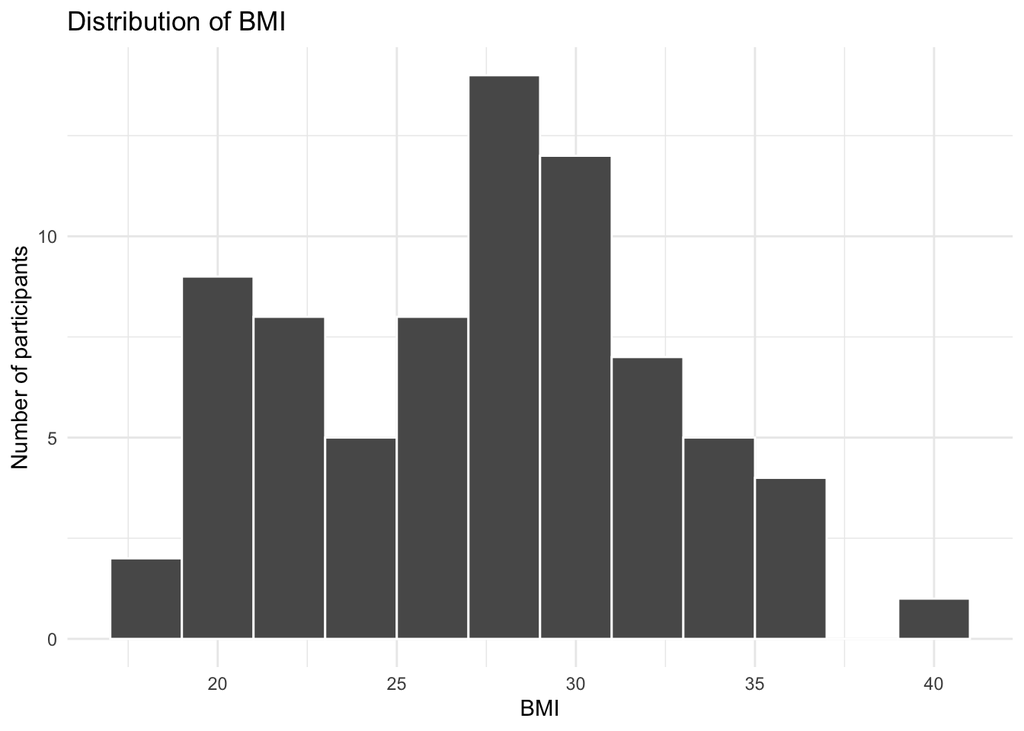

```r
# A histogram shows the distribution of one numeric variable.
# binwidth controls how wide each bar is.
bmi_plot <- ggplot(clean_data, aes(x = bmi)) +
  geom_histogram(binwidth = 2, colour = "white") +
  labs(
    title = "Distribution of BMI",
    x = "BMI",
    y = "Number of participants"
  ) +
  theme_minimal()

bmi_plot
```

```r
# Save the plot as a high-resolution PNG file.
ggsave(
  "figures/article_03_bmi_distribution.png",
  bmi_plot,
  width = 7,
  height = 5,
  dpi = 300
)
```

### HbA1c by diabetes status

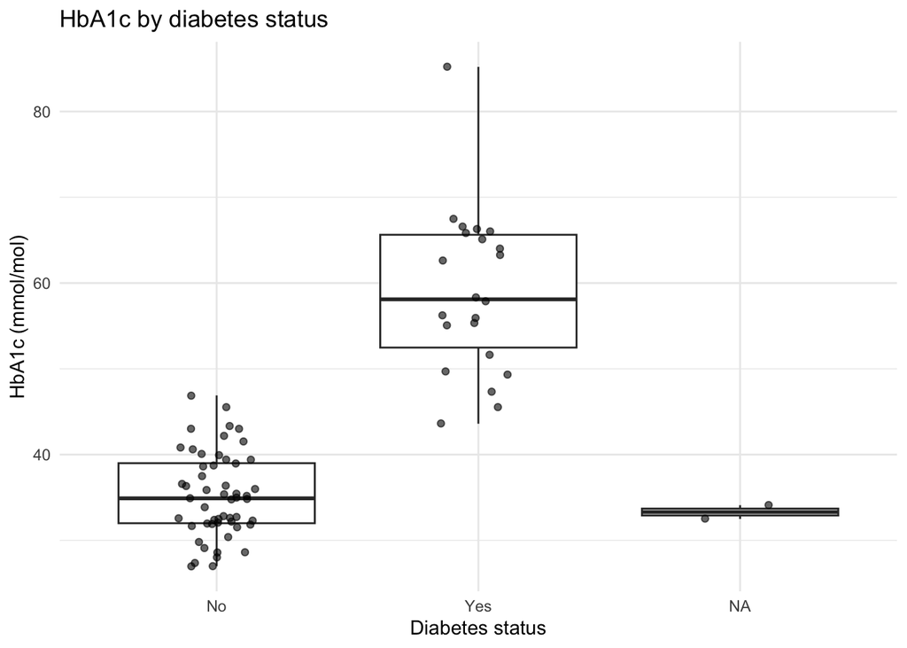

```r
# A boxplot compares a numeric variable across groups.
# geom_jitter() adds individual points so readers can see the raw data pattern.
hba1c_plot <- ggplot(clean_data, aes(x = diabetes_status, y = hba1c_mmol_mol)) +
  geom_boxplot() +
  geom_jitter(width = 0.15, alpha = 0.6) +
  labs(
    title = "HbA1c by diabetes status",
    x = "Diabetes status",
    y = "HbA1c (mmol/mol)"
  ) +
  theme_minimal()

hba1c_plot
```

```r
# Save the HbA1c boxplot.
ggsave(
  "figures/article_03_hba1c_by_diabetes_status.png",
  hba1c_plot,
  width = 7,
  height = 5,
  dpi = 300
)
```

### BMI and HbA1c

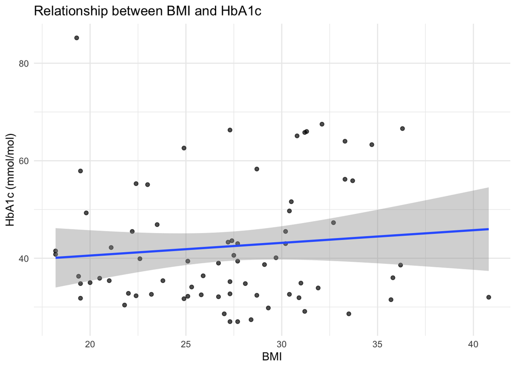

```r
# A scatter plot shows the relationship between two numeric variables.
# geom_smooth(method = "lm") adds a simple linear trend line.
bmi_hba1c_plot <- ggplot(clean_data, aes(x = bmi, y = hba1c_mmol_mol)) +
  geom_point(alpha = 0.7) +
  geom_smooth(method = "lm", se = TRUE) +
  labs(
    title = "Relationship between BMI and HbA1c",
    x = "BMI",
    y = "HbA1c (mmol/mol)"
  ) +
  theme_minimal()

bmi_hba1c_plot
```

```r
# Save the BMI-HbA1c scatter plot.
ggsave(
  "figures/article_03_bmi_hba1c_scatter.png",
  bmi_hba1c_plot,
  width = 7,
  height = 5,
  dpi = 300
)
```

## 13. First simple group comparisons

Descriptive statistics tell us what the data look like. A statistical test asks whether an observed difference is larger than we might expect by chance, under a particular set of assumptions.

**WarningChosing the appropriate statistical test**

A statistical test should follow the research question, study design, variable type, and assumptions. Always take all the above into consideration before choosing a most appropriate test for the question.

## 14. Compare BMI by diabetes status

BMI is numeric. Diabetes status has two groups: `Yes` and `No`.

A simple first comparison is a two-sample t-test.

```r
# t.test(y ~ group, data = dataset) compares the mean of y between groups.
# Here, y is BMI and the group is diabetes status.
bmi_t_test <- t.test(bmi ~ diabetes_status, data = clean_data)

bmi_t_test
```

```
    Welch Two Sample t-test

data:  bmi by diabetes_status
t = -1.8125, df = 42.423, p-value = 0.07699
alternative hypothesis: true difference in means between group No and group Yes is not equal to 0
95 percent confidence interval:
 -4.8877215  0.2616346
sample estimates:
 mean in group No mean in group Yes
         26.60000          28.91304
```

We can store the key result in a small table.

```r
# Store the test result in a tibble so it can be exported and displayed neatly.
bmi_t_test_summary <- tibble(
  comparison = "BMI by diabetes status",
  test = "Two-sample t-test",
  p_value = bmi_t_test$p.value
) %>%
  mutate(
    p_value = case_when(
      p_value < 0.001 ~ "<0.001",
      TRUE ~ as.character(round(p_value, 3))
    )
  )

bmi_t_test_summary_display <- bmi_t_test_summary %>%
  rename(
    Comparison = comparison,
    Test = test,
    `p-value` = p_value
  )

kable(
  bmi_t_test_summary_display,
  caption = "BMI comparison by diabetes status",
  align = "l",
  table.attr = 'class="table table-striped table-hover"'
)
```

BMI comparison by diabetes status

| Comparison | Test | p-value |
| --- | --- | --- |
| BMI by diabetes status | Two-sample t-test | 0.077 |

```r
# Save the t-test summary.
write_csv(bmi_t_test_summary, "outputs/article_03_bmi_t_test_summary.csv")
```

## 15. Compare sex distribution by diabetes status

Sex and diabetes status are both categorical variables. A simple first comparison is a chi-square test.

```r
# table() creates a cross-tabulation of two categorical variables.
sex_diabetes_table <- table(clean_data$sex, clean_data$diabetes_status)

# Convert the table object into a data frame so kable() can display it neatly.
sex_diabetes_table_display <- sex_diabetes_table %>%
  as.data.frame.matrix() %>%
  rownames_to_column(var = "Sex")

kable(
  sex_diabetes_table_display,
  caption = "Sex by diabetes status",
  align = "l",
  table.attr = 'class="table table-striped table-hover"'
)
```

Sex by diabetes status

| Sex | No | Yes |
| --- | --- | --- |
| Female | 30 | 14 |
| Male | 24 | 8 |

```r
# chisq.test() tests whether two categorical variables are associated.
sex_diabetes_chisq <- chisq.test(sex_diabetes_table)

sex_diabetes_chisq
```

```
    Pearson's Chi-squared test with Yates' continuity correction

data:  sex_diabetes_table
X-squared = 0.15284, df = 1, p-value = 0.6958
```

Save the result.

```r
# Store the chi-square result in a small summary table.
sex_diabetes_chisq_summary <- tibble(
  comparison = "Sex by diabetes status",
  test = "Chi-square test",
  p_value = sex_diabetes_chisq$p.value
) %>%
  mutate(
    p_value = case_when(
      p_value < 0.001 ~ "<0.001",
      TRUE ~ as.character(round(p_value, 3))
    )
  )

sex_diabetes_chisq_summary_display <- sex_diabetes_chisq_summary %>%
  rename(
    Comparison = comparison,
    Test = test,
    `p-value` = p_value
  )

kable(
  sex_diabetes_chisq_summary_display,
  caption = "Chi-square test summary",
  align = "l",
  table.attr = 'class="table table-striped table-hover"'
)
```

Chi-square test summary

| Comparison | Test | p-value |
| --- | --- | --- |
| Sex by diabetes status | Chi-square test | 0.696 |

```r
# Save the chi-square summary.
write_csv(sex_diabetes_chisq_summary, "outputs/article_03_sex_diabetes_chisq_summary.csv")
```

**NoteA note about p-values**

A p-value does not tell us whether a result is clinically important. It only helps assess how compatible the observed data are with a null hypothesis under the assumptions of the test.

Clinical judgement, study design, sample size, effect size, confidence intervals, and prior evidence all matter.

## 16. Add confidence intervals for a mean

Confidence intervals are often more informative than p-values alone. Here is a simple example using mean BMI.

```r
# Calculate a 95% confidence interval for the mean BMI.
# The standard error estimates how precisely the sample mean estimates the population mean.
bmi_mean_ci <- clean_data %>%
  summarise(
    n = sum(!is.na(bmi)),
    mean_bmi = mean(bmi, na.rm = TRUE),
    sd_bmi = sd(bmi, na.rm = TRUE),
    standard_error = sd_bmi / sqrt(n),
    lower_95_ci = mean_bmi - 1.96 * standard_error,
    upper_95_ci = mean_bmi + 1.96 * standard_error
  ) %>%
  mutate(across(where(is.numeric), ~ round(.x, 2)))

bmi_mean_ci_display <- bmi_mean_ci %>%
  rename(
    N = n,
    `Mean BMI` = mean_bmi,
    `SD BMI` = sd_bmi,
    `Standard error` = standard_error,
    `Lower 95% CI` = lower_95_ci,
    `Upper 95% CI` = upper_95_ci
  )

kable(
  bmi_mean_ci_display,
  caption = "Mean BMI with 95% confidence interval",
  digits = 2,
  align = "l",
  table.attr = 'class="table table-striped table-hover"'
)
```

Mean BMI with 95% confidence interval

| N | Mean BMI | SD BMI | Standard error | Lower 95% CI | Upper 95% CI |
| --- | --- | --- | --- | --- | --- |
| 75 | 27.28 | 5.06 | 0.58 | 26.14 | 28.43 |

```r
# Save the confidence interval table.
write_csv(bmi_mean_ci, "outputs/article_03_bmi_mean_confidence_interval.csv")
```

## 17. Export a simple analysis summary

It is useful to save important outputs rather than relying only on what appears in the console.

```r
# Combine the two simple test summaries into one analysis summary table.
analysis_summary <- bind_rows(
  bmi_t_test_summary,
  sex_diabetes_chisq_summary
)

analysis_summary_display <- analysis_summary %>%
  rename(
    Comparison = comparison,
    Test = test,
    `p-value` = p_value
  )

kable(
  analysis_summary_display,
  caption = "Summary of simple group comparisons",
  align = "l",
  table.attr = 'class="table table-striped table-hover"'
)
```

Summary of simple group comparisons

| Comparison | Test | p-value |
| --- | --- | --- |
| BMI by diabetes status | Two-sample t-test | 0.077 |
| Sex by diabetes status | Chi-square test | 0.696 |

```r
# Save the analysis summary.
write_csv(analysis_summary, "outputs/article_03_simple_analysis_summary.csv")
```

## 18. Mini activity

Using the cleaned dataset, try to answer these questions.

1. What is the median age of the sample?
2. What percentage of participants have diabetes?
3. What is the median HbA1c by diabetes status?
4. Make a boxplot of systolic blood pressure by diabetes status.
5. Create a simple Table 1 by study group.

## 19. What comes next?

You now have a clean beginner workflow:

1. Article 1: learn R basics and inspect a clean dataset.
2. Article 2: clean a messy clinical dataset reproducibly.
3. Article 3: summarise the cleaned dataset and create first tables, plots, and comparisons.

Next, we will focus on how to choose statistical tests more carefully, including:

- paired vs unpaired data;
- parametric vs non-parametric tests;
- simple linear and logistic regression.

## Appendix

You can download the files used in this article here:

1. [View all the files used to create this article on GitHub](https://github.com/Ziyao-Geng/RISE-Data-Science-Articles/tree/main/article_03_descriptive_statistics_table1)
2. Download the sample cleaned health dataset used to create the outputs
3. Download the Quarto file used to create this article